# BMS vs BCR: Initial trials as an exploration of informativity

Joel Eliason

### Introduction

In this notebook, we will be examining two simple cases, in one and two dimensions. In particular, I will be examining the informativity of additional trials run from multiple initial conditions. In all cases, $n$ (the total amount of data) will remain the same - therefore, for multiple ICs, the amount of data per trial will be less than it would be if there was only one IC. Furthermore, I will not be investigating sampling rate in this notebook - however, I will be exploring briefly the effects of various levels of noise at the end of the notebook

##### Variables to be recorded (per coefficient)

- Posterior mean
- Posterior standard deviation
- Probability of inclusion
- General shape of posterior (e.g. Gaussan, skewed right)
- Rank of true model
- Expected model size
- Posterior model probabilities (top 3)

### 1D case

Here we have the system defined by
$$\begin{equation}
\dot{x}=x-0.2x^{3}-0.1x^{4}
\end{equation}$$

We’ll be using three different initial conditions for this experiment: $x(0)=0.1$, $x(0)=1/2$ and $x(0)=5$. Let’s solve for all trajectories out to $t_{f}=5$ and then see how well Bayesian model averaging recovers the coefficients when just using the data alone from each trajectory.

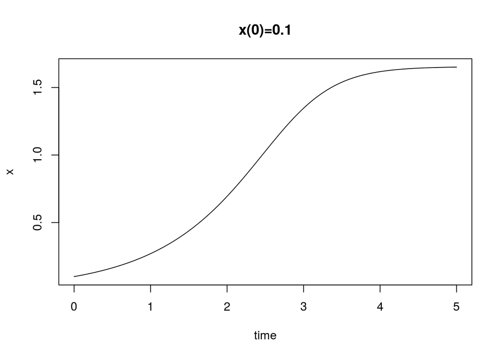

```r
parameters<-c(a=1,b=-0.2,c=-0.1)
step=0.01
simple1d<-function(t,state,parameters){
    a<-parameters[[1]]
    b<-parameters[[2]]
    c<-parameters[[3]]
    x<-state
    dx<-a*x+b*x**3+c*x**4
    list(dx)
}
times<-seq(0,5,by=step)
# simple_trial<-function(t,state,parameters){
#     x<-state
#     dx<-x-0.1*x**3-0.2*x**4
#     list(dx)
# }
#
#
# ic<-c(x=0.1)
# sol_trial<-ode(y=ic,times=times,func=simple_trial,parms=c(3,4))
# plot(sol_trial,xlab="time",ylab="x",main="trial")

state<-c(x=0.1)
sol1<-ode(y=state,times=times,func=simple1d,parms=parameters)
plot(sol1,xlab="time",ylab="x",main="x(0)=0.1")
```

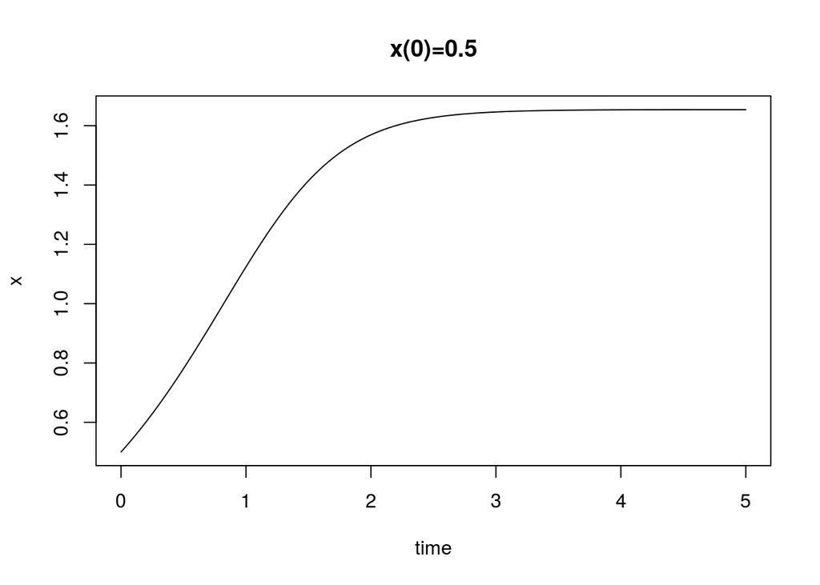

```r
state<-c(x=0.5)
sol2<-ode(y=state,times=times,func=simple1d,parms=parameters)
plot(sol2,xlab="time",ylab="x",main="x(0)=0.5")
```

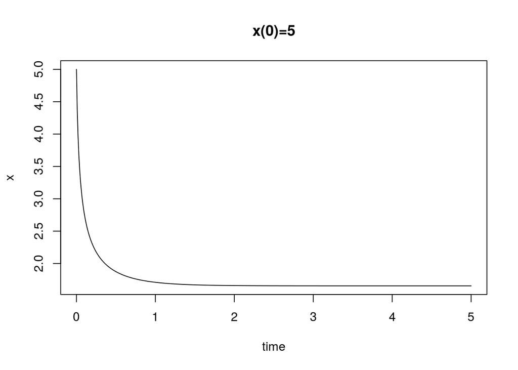

```r
state<-c(x=5)
sol3<-ode(y=state,times=times,func=simple1d,parms=parameters)
plot(sol3,xlab="time",ylab="x",main="x(0)=5")
```

Let’s recover the derivatives for these systems:

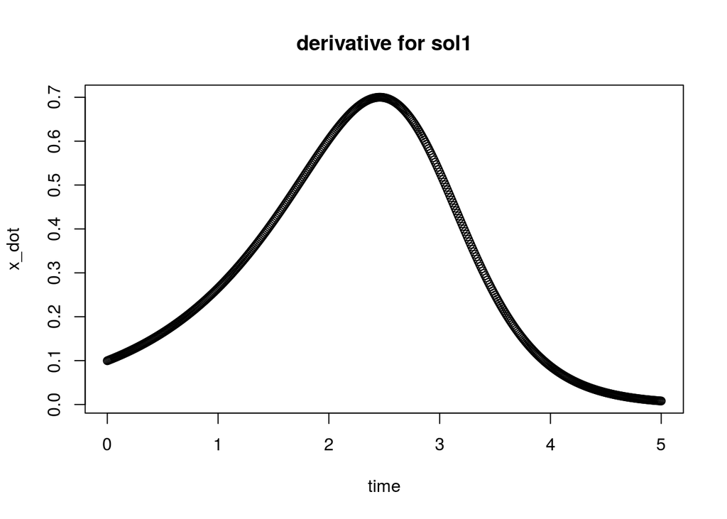

```r
# deriv<-function(t,state,parameters){
#   with(as.list(c(state,parameters)),{
#     dx<-a*x+b*x**3+c*x**4
#     list(dx)
#   })
# }
x<-sol1[,2]
y<-sapply(x,simple1d,t=0,parameters=parameters)
y1<-unlist(y)
plot(times,y1,xlab="time",ylab="x_dot",main="derivative for sol1")
```

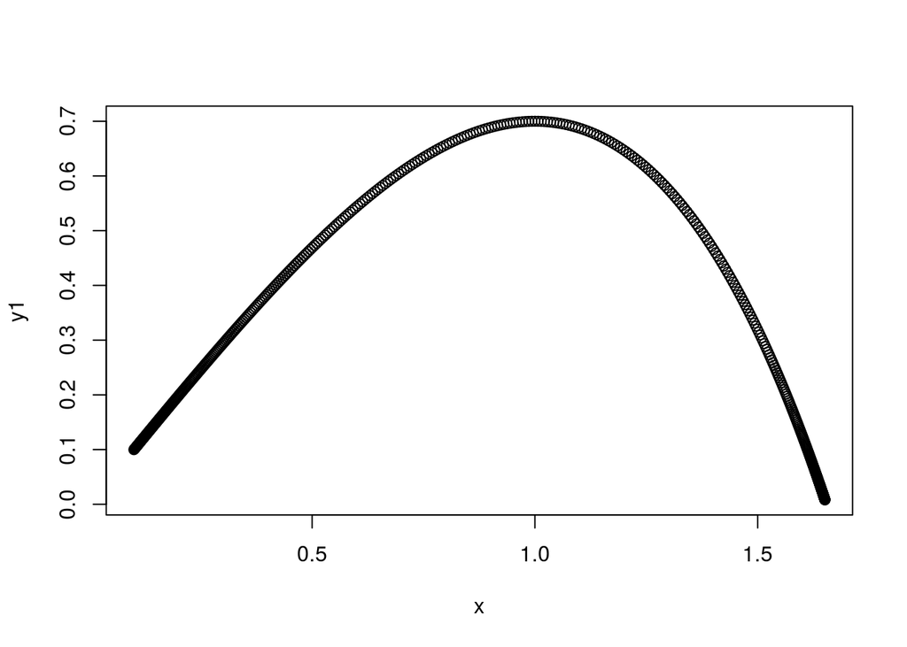

```r
plot(x,y1)
```

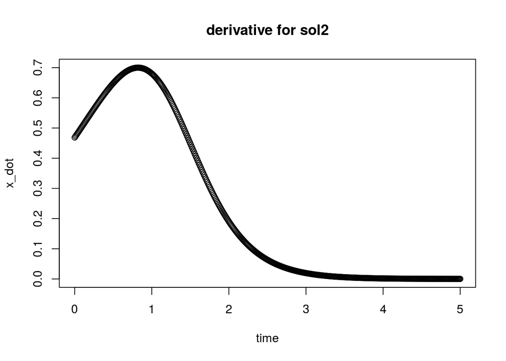

```r
x<-sol2[,2]
y<-sapply(x,simple1d,t=0,parameters=parameters)
y2<-unlist(y)
plot(times,y2,xlab="time",ylab="x_dot",main="derivative for sol2")
```

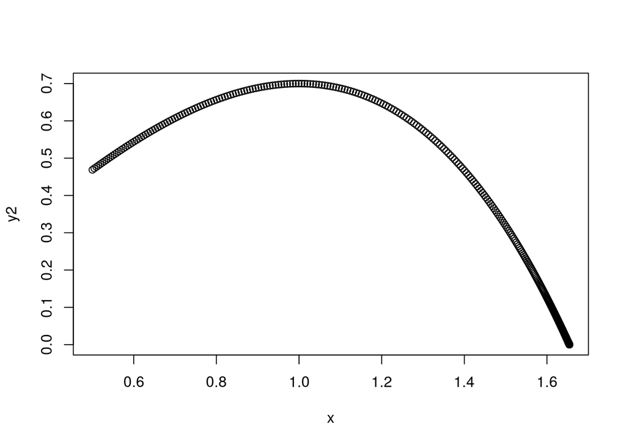

```r
plot(x,y2)
```

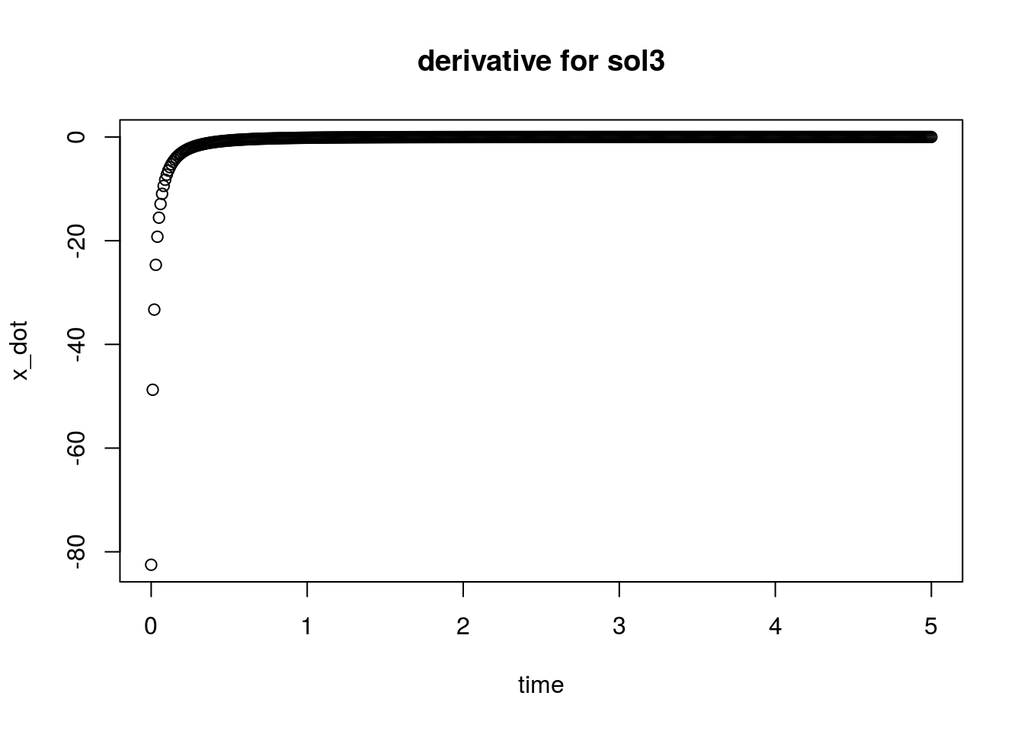

```r
x<-sol3[,2]
y<-sapply(x,simple1d,t=0,parameters=parameters)
y3<-unlist(y)
plot(times,y3,xlab="time",ylab="x_dot",main="derivative for sol3")
```

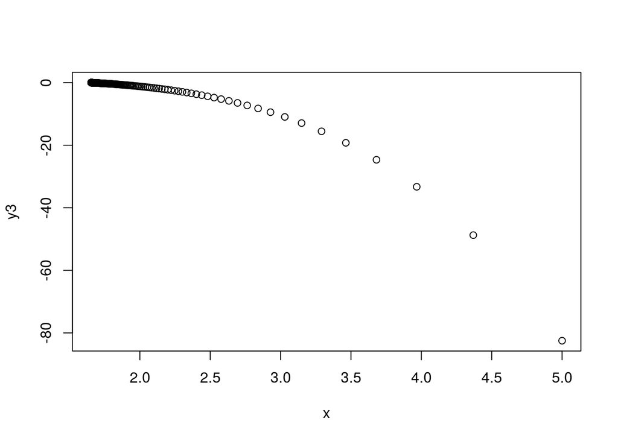

```r
plot(x,y3)
```

Next, let’s try recovering coefficients from each of these systems using the BMS regression function (on default settings) and compare:

### IC 1

```r
N<-50
num_models<-5
set.seed(12)
sig=0.01
d<-4
x<-poly(sol1[,2],d,raw=TRUE)
noise<-rnorm(n=N,sd=sig)
data1<-data.frame(y1,x)
data1<-data1[1:N,]
data1[,1]<-data1[,1]+noise
# data1[,2:ncol(data1)]<-scale(data1[,2:ncol(data1)])
cor(data1)
```

```
##           y1        X1        X2        X3        X4
## y1 1.0000000 0.9126589 0.9042050 0.8927907 0.8789385
## X1 0.9126589 1.0000000 0.9979929 0.9921733 0.9829727
## X2 0.9042050 0.9979929 1.0000000 0.9980826 0.9925969
## X3 0.8927907 0.9921733 0.9980826 1.0000000 0.9982050
## X4 0.8789385 0.9829727 0.9925969 0.9982050 1.0000000
```

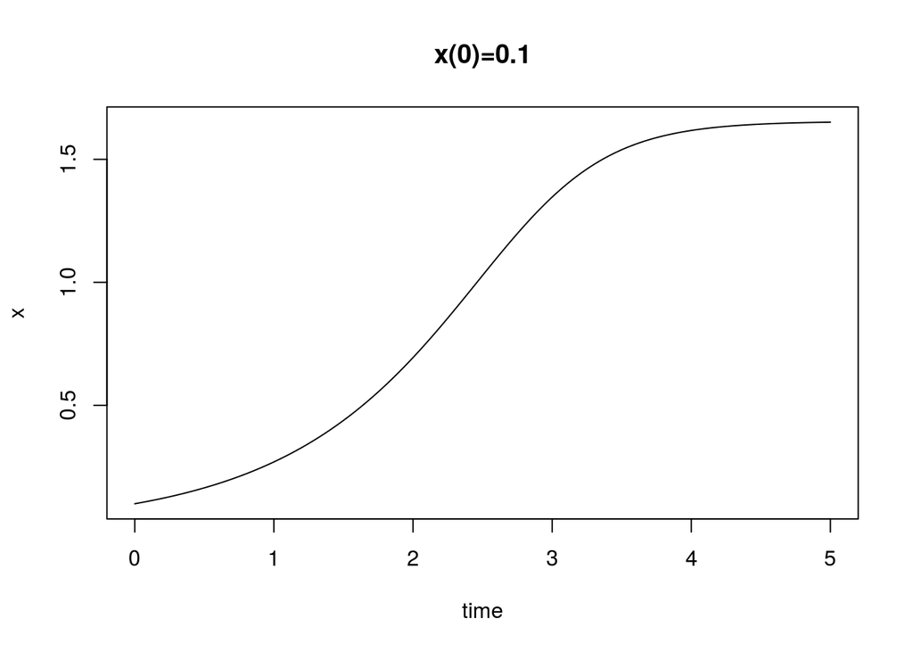

```r
plot(sol1,xlab="time",ylab="x",main="x(0)=0.1")
```

```r
cor(data1[1:N,2],data1[1:N,2],method="spearman")
```

```
## [1] 1
```

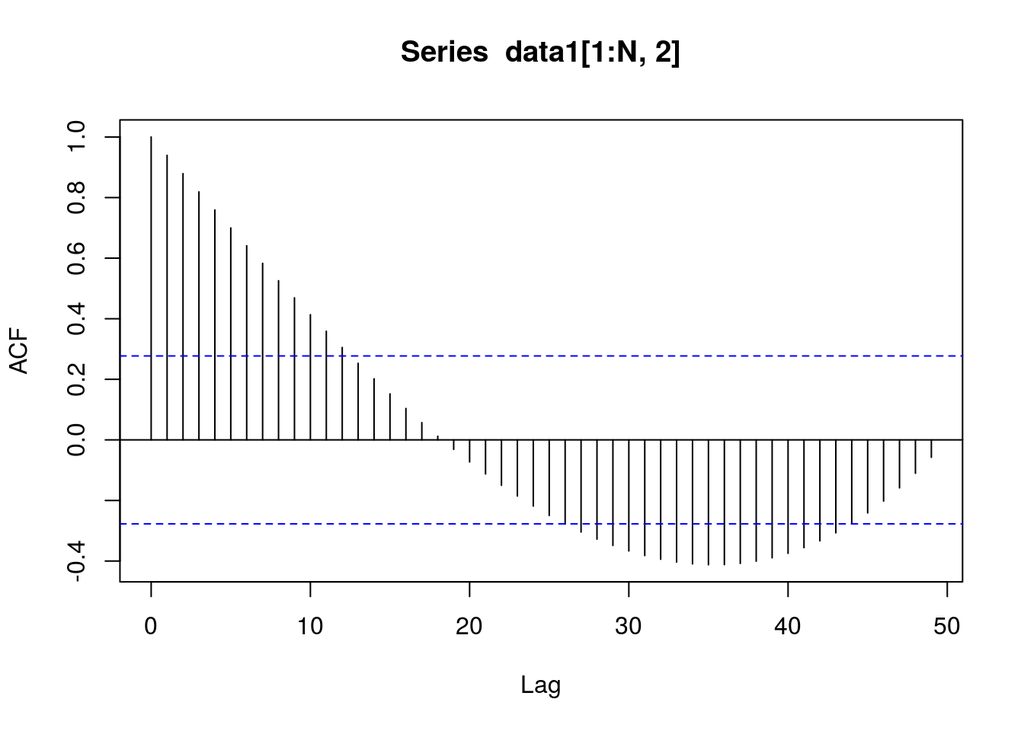

```r
acf(data1[1:N,2],lag.max=N)
```

```r
reg<-bms(data1)
```

```
##          PIP   Post Mean    Post SD Cond.Pos.Sign Idx
## X1 0.7112833   -4.497526   42.67572     0.9357367   1
## X2 0.4597016   80.305980  502.48299     0.6042296   2
## X3 0.4031850 -470.424778 2615.80137     0.2338350   3
## X4 0.3826765  963.146224 5075.94320     0.4455593   4
##
## Mean no. regressors               Draws             Burnins
##            "1.9568"                "16"                 "0"
##                Time  No. models visited      Modelspace 2^K
##    "0.2040546 secs"                "16"                "16"
##           % visited         % Topmodels            Corr PMP
##               "100"               "100"                "NA"
##            No. Obs.         Model Prior             g-Prior
##                "50"        "random / 2"               "UIP"
##     Shrinkage-Stats
##         "Av=0.9804"
##
## Time difference of 0.2040546 secs
```

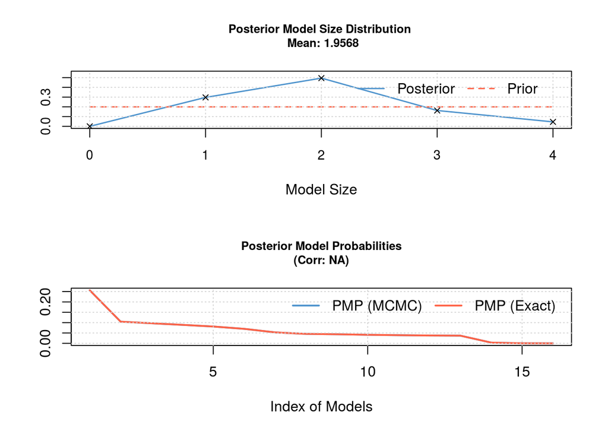

```r
# coef(reg)
topmodels.bma(reg)[,1:num_models]
```

```
##                    08        0c         0a         09         06
## X1          1.0000000 1.0000000 1.00000000 1.00000000 0.00000000
## X2          0.0000000 1.0000000 0.00000000 0.00000000 1.00000000
## X3          0.0000000 0.0000000 1.00000000 0.00000000 1.00000000
## X4          0.0000000 0.0000000 0.00000000 1.00000000 0.00000000
## PMP (Exact) 0.2561786 0.1046201 0.09692841 0.08924789 0.08117098
## PMP (MCMC)  0.2561786 0.1046201 0.09692841 0.08924789 0.08117098
```

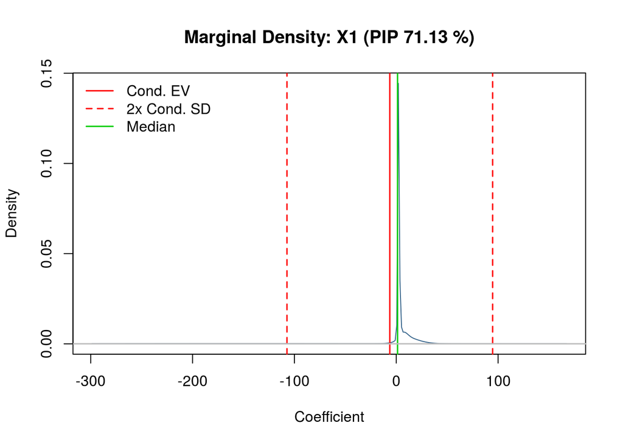

```r
# image(reg)
# plotModelsize(reg)
density(reg, reg = "X1")
```

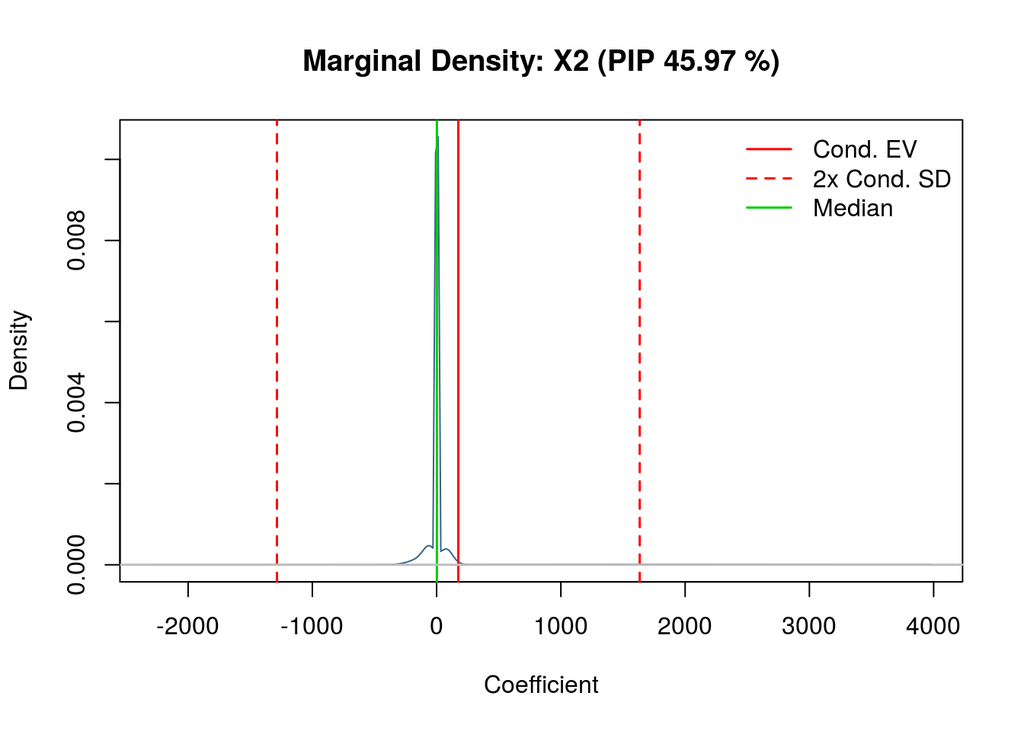

```r
density(reg, reg = "X2")
```

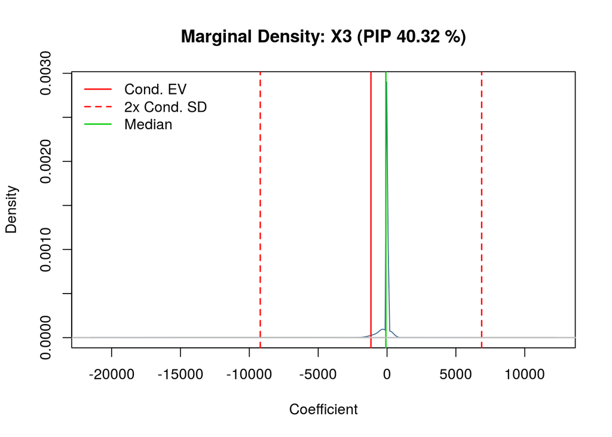

```r
density(reg, reg = "X3")
```

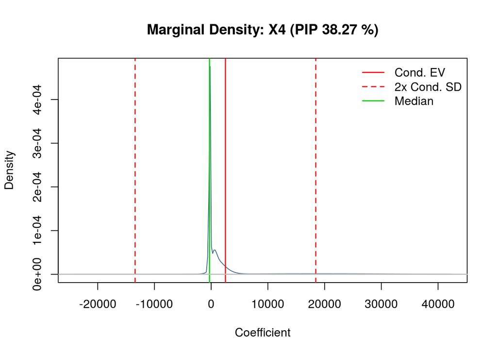

```r
density(reg, reg = "X4")
```

### IC 2

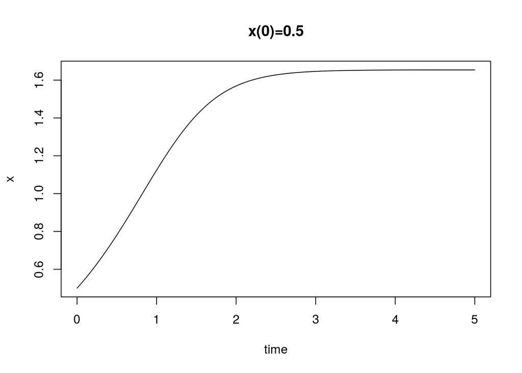

```r
x<-poly(sol2[,2],d,raw=TRUE)
data2<-data.frame(y2,x)
data2<-data2[1:N,]
data2[,1]<-data2[,1]+noise
# data1[,2:ncol(data1)]<-scale(data1[,2:ncol(data1)])
plot(sol2,xlab="time",ylab="x",main="x(0)=0.5")
```

```r
cor(data2[1:N,2],data2[1:N,2],method="spearman")
```

```
## [1] 1
```

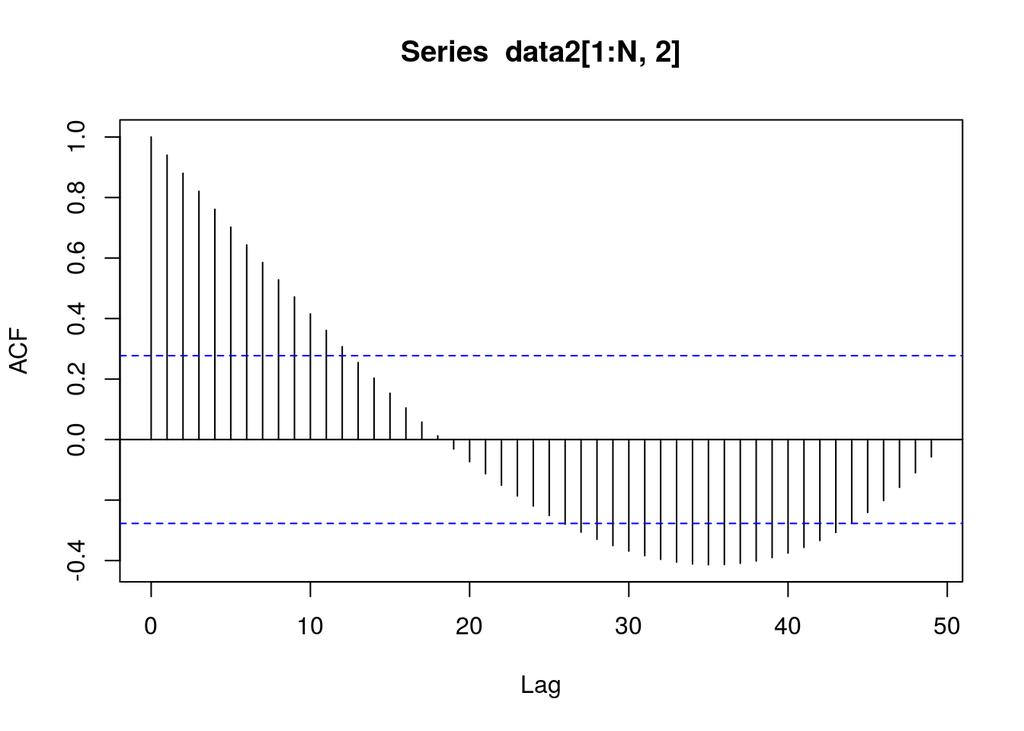

```r
acf(data2[1:N,2],lag.max=N)
```

```r
cor(data2)
```

```
##           y2        X1        X2        X3        X4
## y2 1.0000000 0.9826813 0.9749930 0.9644955 0.9515770
## X1 0.9826813 1.0000000 0.9983864 0.9936847 0.9861898
## X2 0.9749930 0.9983864 1.0000000 0.9984487 0.9939776
## X3 0.9644955 0.9936847 0.9984487 1.0000000 0.9985331
## X4 0.9515770 0.9861898 0.9939776 0.9985331 1.0000000
```

```r
reg<-bms(data2)
```

```
##          PIP  Post Mean  Post SD Cond.Pos.Sign Idx
## X1 0.6606636 -0.9854023 15.53359     0.9368903   1
## X2 0.5809661  5.5091592 37.33856     0.5471750   2
## X3 0.5293837 -6.4557496 39.76810     0.2013930   3
## X4 0.4873322  2.3919891 15.82902     0.3664383   4
##
## Mean no. regressors               Draws             Burnins
##            "2.2583"                "16"                 "0"
##                Time  No. models visited      Modelspace 2^K
##   "0.03671479 secs"                "16"                "16"
##           % visited         % Topmodels            Corr PMP
##               "100"               "100"                "NA"
##            No. Obs.         Model Prior             g-Prior
##                "50"        "random / 2"               "UIP"
##     Shrinkage-Stats
##         "Av=0.9804"
##
## Time difference of 0.03671479 secs
```

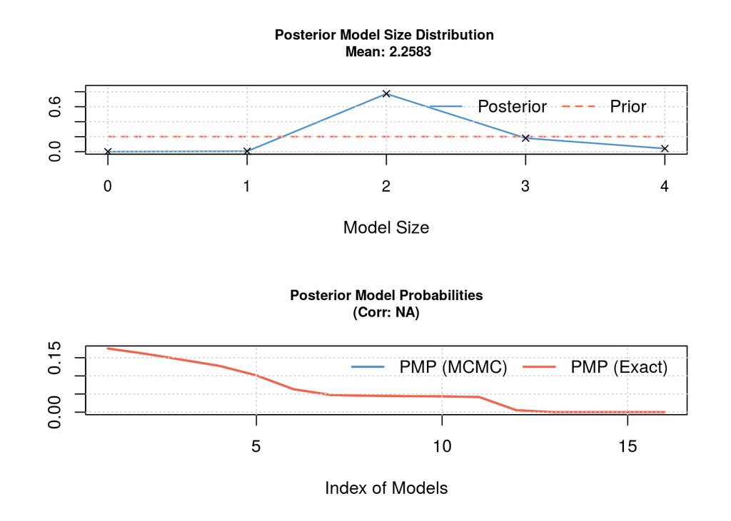

```r
# coef(reg)
topmodels.bma(reg)[,1:num_models]
```

```
##                    0c        0a        09        06        05
## X1          1.0000000 1.0000000 1.0000000 0.0000000 0.0000000
## X2          1.0000000 0.0000000 0.0000000 1.0000000 1.0000000
## X3          0.0000000 1.0000000 0.0000000 1.0000000 0.0000000
## X4          0.0000000 0.0000000 1.0000000 0.0000000 1.0000000
## PMP (Exact) 0.1753962 0.1608983 0.1442878 0.1275001 0.1013268
## PMP (MCMC)  0.1753962 0.1608983 0.1442878 0.1275001 0.1013268
```

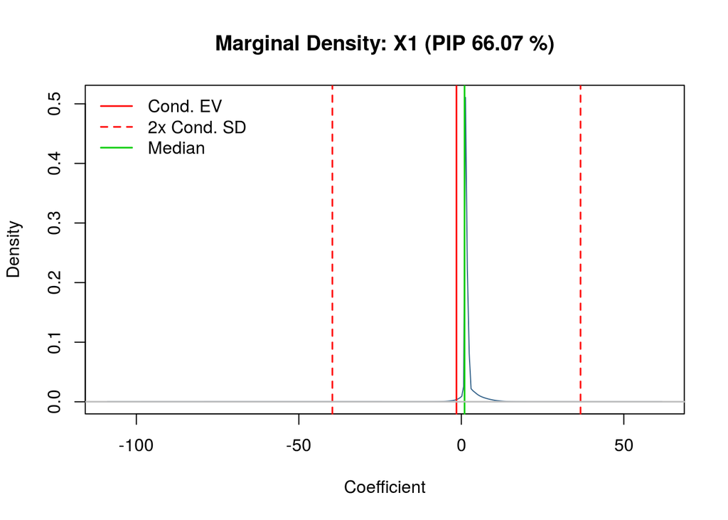

```r
# image(reg)
# plotModelsize(reg)
density(reg, reg = "X1")
```

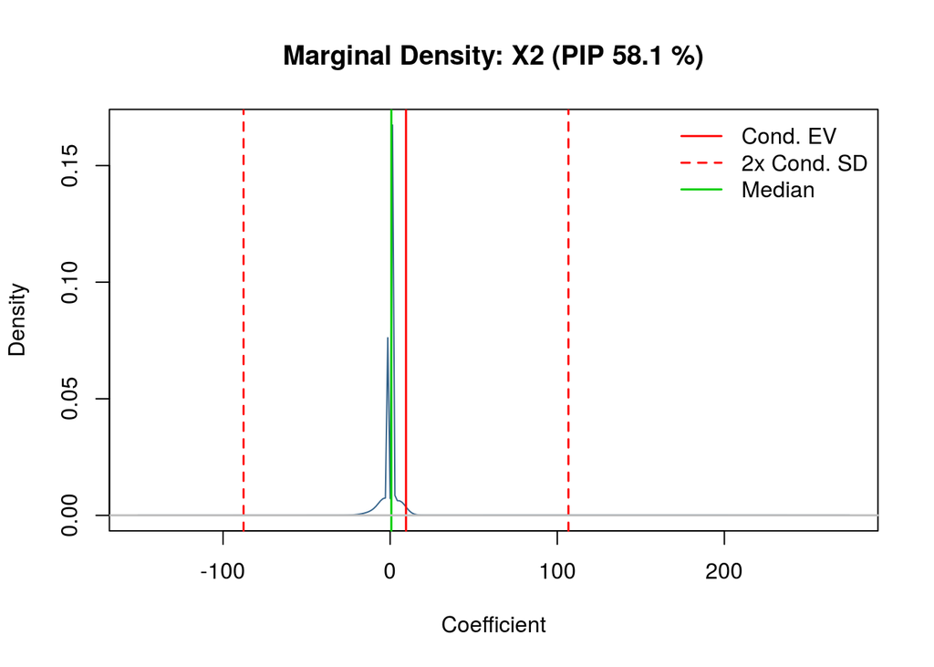

```r
density(reg, reg = "X2")
```

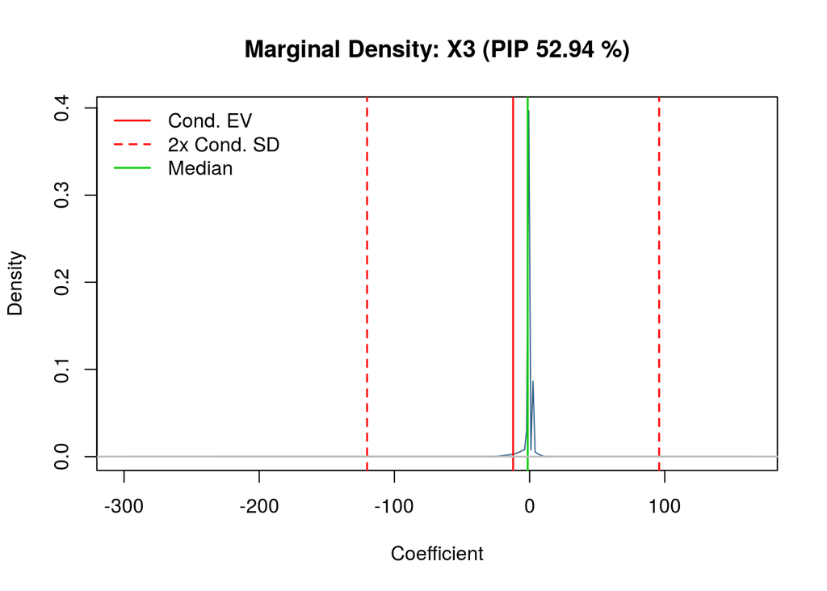

```r
density(reg, reg = "X3")
```

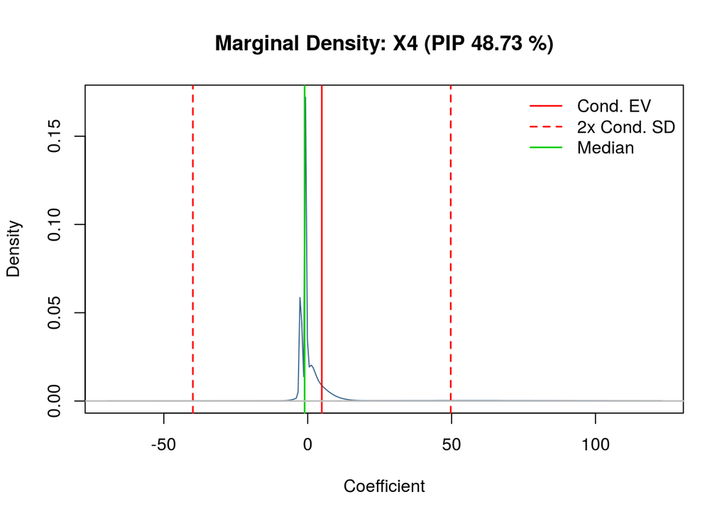

```r
density(reg, reg = "X4")
```

### IC 3

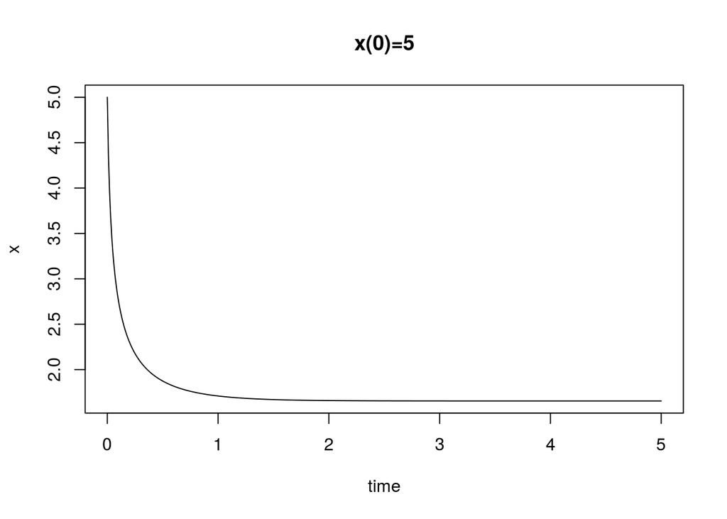

```r
x<-poly(sol3[,2],d,raw=T)
data3<-data.frame(y3,x)
data3<-data3[1:N,]
data3[,1]<-data3[,1]+noise
# data3[,2:ncol(data3)]<-scale(data3[,2:ncol(data3)])
plot(sol3,xlab="time",ylab="x",main="x(0)=5")
```

```r
cor(data3[1:N,2],data3[1:N,2],method="spearman")
```

```
## [1] 1
```

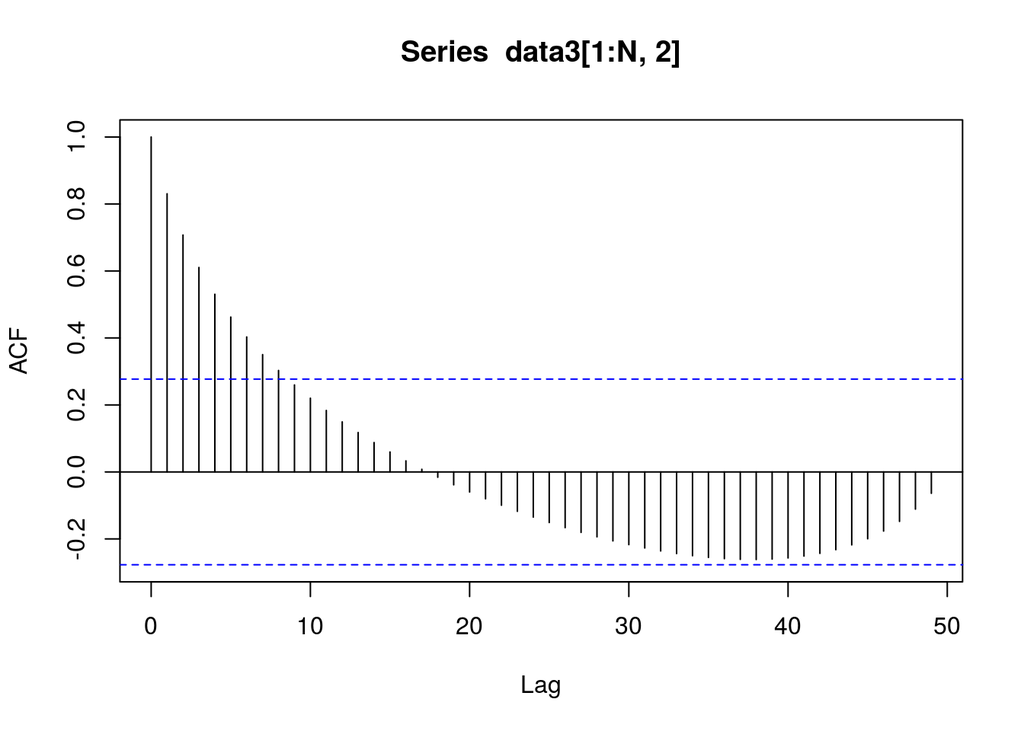

```r
acf(data3[1:N,2],lag.max=N)
```

```r
cor(data3)
```

```
##            y3         X1         X2         X3         X4
## y3  1.0000000 -0.9220989 -0.9685472 -0.9940548 -0.9997880
## X1 -0.9220989  1.0000000  0.9890239  0.9581919  0.9144572
## X2 -0.9685472  0.9890239  1.0000000  0.9898015  0.9634150
## X3 -0.9940548  0.9581919  0.9898015  1.0000000  0.9916481
## X4 -0.9997880  0.9144572  0.9634150  0.9916481  1.0000000
```

```r
reg<-bms(data3)
```

```
##          PIP  Post Mean     Post SD Cond.Pos.Sign Idx
## X4 0.8694809 -0.1100681  0.08827738     0.0000000   4
## X3 0.2598659 -0.1573069  1.05757196     0.0000000   3
## X2 0.2171827  0.2207782  4.88858096     0.4732652   2
## X1 0.1918438  0.2125297 10.42602550     0.4816055   1
##
## Mean no. regressors               Draws             Burnins
##            "1.5384"                "16"                 "0"
##                Time  No. models visited      Modelspace 2^K
##  "0.002579451 secs"                "16"                "16"
##           % visited         % Topmodels            Corr PMP
##               "100"               "100"                "NA"
##            No. Obs.         Model Prior             g-Prior
##                "50"        "random / 2"               "UIP"
##     Shrinkage-Stats
##         "Av=0.9804"
##
## Time difference of 0.002579451 secs
```

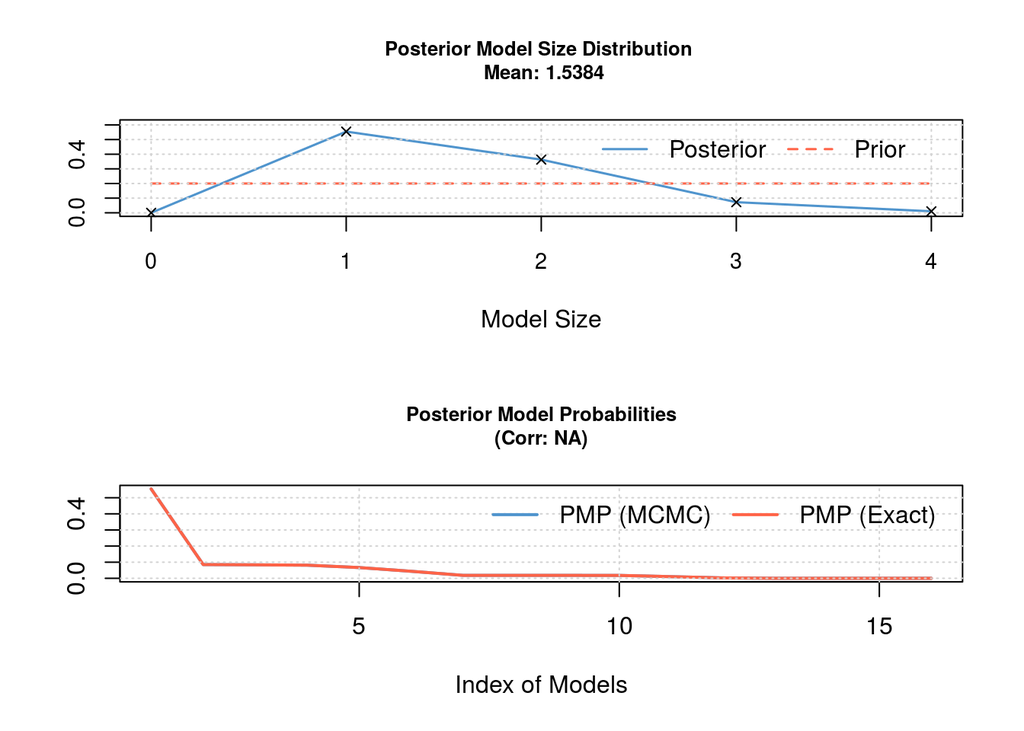

```r
# coef(reg)
topmodels.bma(reg)[,1:num_models]
```

```
##                    01        03         05         09         06
## X1          0.0000000 0.0000000 0.00000000 1.00000000 0.00000000
## X2          0.0000000 0.0000000 1.00000000 0.00000000 1.00000000
## X3          0.0000000 1.0000000 0.00000000 0.00000000 1.00000000
## X4          1.0000000 1.0000000 1.00000000 1.00000000 0.00000000
## PMP (Exact) 0.5544242 0.0852374 0.08366237 0.08148765 0.06665985
## PMP (MCMC)  0.5544242 0.0852374 0.08366237 0.08148765 0.06665985
```

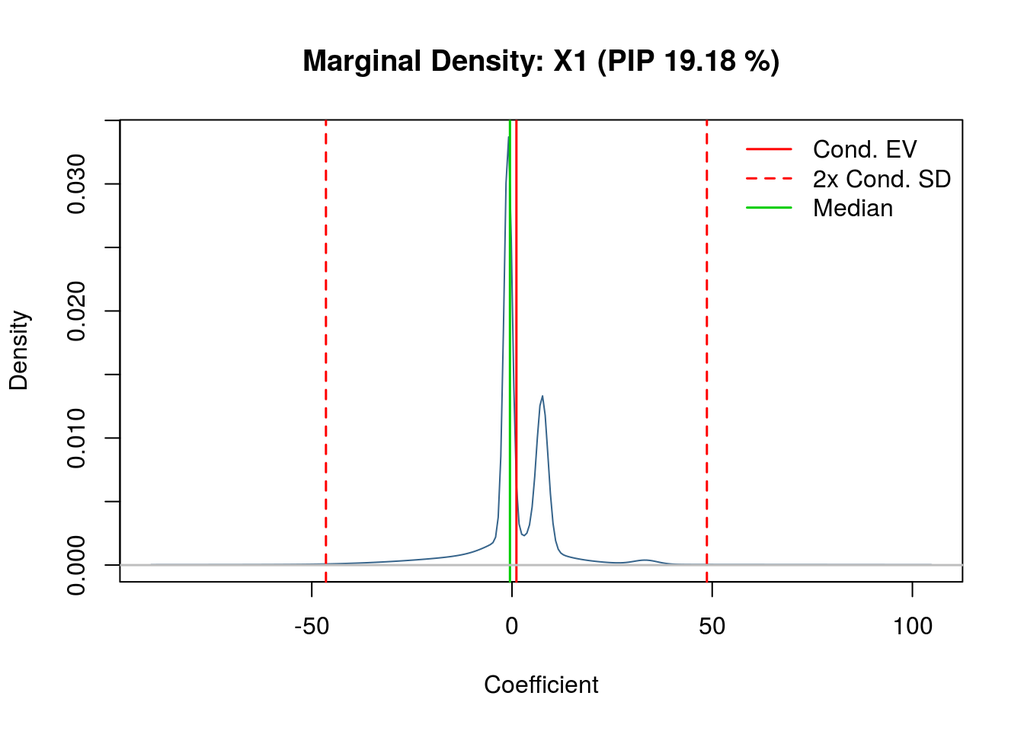

```r
# image(reg)
# plotModelsize(reg)
density(reg, reg = "X1")
```

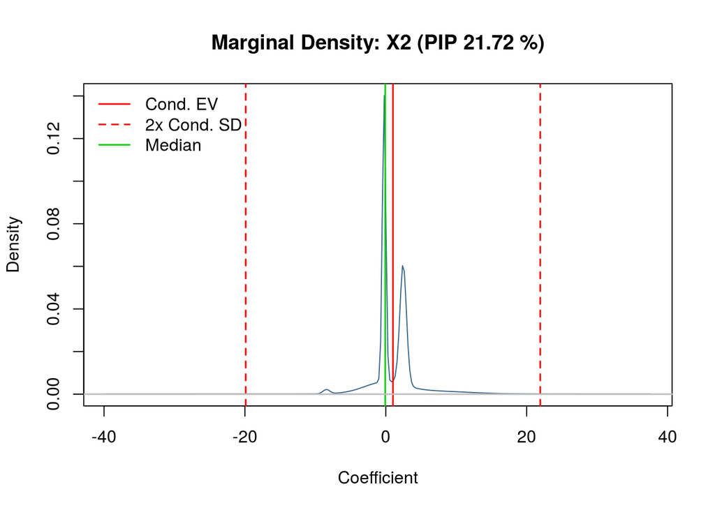

```r
density(reg, reg = "X2")
```

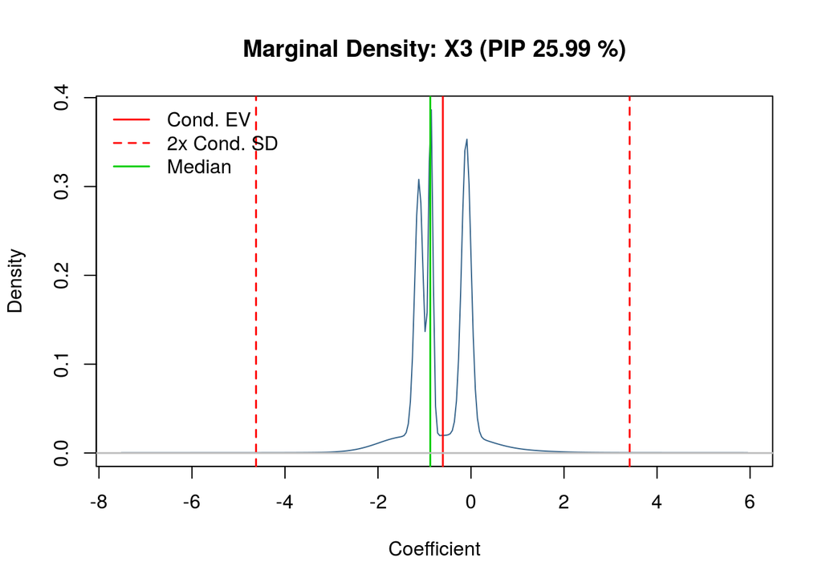

```r
density(reg, reg = "X3")
```

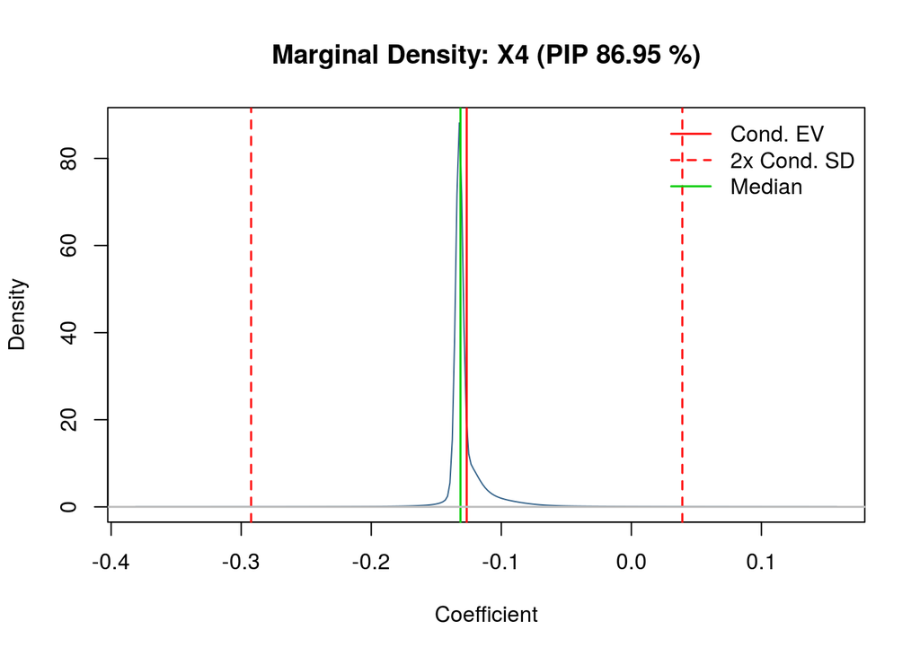

```r
density(reg, reg = "X4")
```